# **A Deep-Dive into the Golden State Warriors' Success During the Years 2015-2023 and How it Could Shed Light on Other Team's Performances**

## **Spring 2024 Data Science Project**

### **Aditi Hegde, Sarah Kee, Pranav Bolla**

### **Contribution**

Member 1: Aditi Hegde, Contribution: 100%

Member 2: Sarah Kee, Contribution: 100%

Member 3: Pranav Bolla, Contribution: 100%

We, all team members, agree together that the above information is true, and we are confident about our contributions to this submitted project/final tutorial.

Aditi Hegde, Sarah Kee, Pranav Bolla (5/5/2024)

Aditi Hegde: Aditi contributed through all the checkpoints. She had great ideas for Checkpoint 2 when we were initially analyzing the NBA data. Furthermore, she worked hard on the ML task in Checkpoint 3 to help us answer our initial questions posed. Aditi was always available via text if we had any questions!

Sarah Kee: Sarah delivered in her work as she helped with the assignments given. She liked the idea of analyzing NBA data because of her prior experience playing and thought it would be a good idea. Additionally, she worked hard on Checkpoint 3 as focused on cleaning/processing the data as well as working on the exploratory analysis/hypothesis testing.

Pranav: Pranav provided help with all the checkpoints. Because he enjoys watching basketball, he gave the idea to use NBA data and create analyses from there. He provided the data prociessing and statistical distribution model for the first two check points, and helped us pivot for the final project.

**These are some specific contribution examples, but overall, we worked on this project together and reviewed it as a team.**

### **1. Introduction**

The Golden State Warriors went to the NBA Finals from the years 2015-2019, 2022. Out of those six final runs, they won 4/6 of them (2015, 2017, 2018, 2022). However, to get to the finals this many times, the Warriors need to be a solid team with many strengths and skills. It is amazing to see one team be so dominant for a great period of time. The Warriors have arguably one of the best players: Stephen Curry. He is known for his three-point shooting and his efficiency. We want to see why the Warriors were such a dominant team during the period 2015-2023 and understand what statistics are important to be successful in the league’s competitive environment. Clearly, their organization is doing something right to stay competitive all these years. Throughout our analysis, we are going to look at the Warriors data and also compare it with the rest of the league to understand the Warriors’ dominance and how the league has changed their play overtime. We will also look at what it means to be a great team in the NBA right now and what teams should focus on during training and draft picks.

### **2. Data Collection**

We will be using the [NBA API](https://github.com/swar/nba_api) to scrape data from NBA games. We chose this data set because it is one of the most popular API’s for NBA data and there is lots of functionality to choose from because of the large data set. Specifically, we are going to focus on NBA Player Game Log Data. We have downloaded this data to use within our project. Furthermore, we will use [NBA Player Stats](https://www.kaggle.com/datasets/justinas/nba-players-data) that provides information about a player's physical status (age, weight, height, etc). We will implement this dataset for the ML models.

### **3. Data Cleaning / Processing**

Now, we must transform the data, so it's ready for analysis. Not only do we need to create a usable dataframe, but we need to "clean" it. Cleaning data is the process of fixing or removing data that is incorrect, wrongly formatted, incomplete, etc. This is useful because we can focus our data to what is relevant for our problem, which smoothens the process for future steps in the data science pipeline.

First, let's import relevant Python libraries.

```python
import pandas as pd
import numpy as np
from scipy import stats
from matplotlib import pyplot as plt
from sklearn.model_selection import train_test_split
from sklearn.linear_model import LogisticRegression
from sklearn.metrics import accuracy_score, confusion_matrix, roc_auc_score
from sklearn.ensemble import RandomForestRegressor
from sklearn.metrics import mean_squared_error
```

Importing data from CSV files into pandas DataFrames

```python
from google.colab import drive
drive.mount('/content/drive')
```

```python
# df_main_data = pd.read_csv('nba_player_game_log_data_for_pranav.csv')

df_main_data = pd.read_csv('/content/drive/MyDrive/Colab Notebooks/nba_player_game_log_data.csv')

print(df_main_data.head())
```

```
   yearSeason slugSeason slugLeague      typeSeason    dateGame    idGame  \
0        2010    2009-10        NBA  Regular Season  2009-10-27  20900004
1        2010    2009-10        NBA  Regular Season  2009-10-27  20900002
2        2010    2009-10        NBA  Regular Season  2009-10-27  20900002
3        2010    2009-10        NBA  Regular Season  2009-10-27  20900002
4        2010    2009-10        NBA  Regular Season  2009-10-27  20900002

   numberGameTeamSeason              nameTeam      idTeam  isB2B  ...  pf  \
0                     1  Los Angeles Clippers  1610612746      0  ...   4
1                     1    Washington Wizards  1610612764      0  ...   0
2                     1    Washington Wizards  1610612764      0  ...   3
3                     1      Dallas Mavericks  1610612742      0  ...   4
4                     1    Washington Wizards  1610612764      0  ...   2

   pts plusminus  fpts                                  urlTeamSeasonLogo  \
```

[output cut: 42 more lines]

Now that we have our pandas dataframes, we want to trim unnecessary information because these datasets have a lot of data that is irrelevant to this project.

```python
# Condensing df to only relevant columns
columns = ['yearSeason', 'dateGame', 'nameTeam', 'locationGame', 'slugTeam', 'slugOpponent',
            'slugTeamWinner', 'slugTeamLoser', 'outcomeGame', 'namePlayer', 'idPlayer', 'isWin', 'fgm', 'fga',
            'pctFG', 'fg3m', 'fg3a', 'pctFG3', 'pctFT', 'fg2m', 'fg2a', 'pctFG2', 'minutes', 'ftm', 'fta',
            'oreb', 'dreb', 'treb', 'ast', 'stl', 'blk', 'tov', 'pf', 'pts']
df_nba_data = pd.DataFrame(df_main_data, columns=columns)

# We only need data from 2015-23, so we can limit the df to these years
df_nba_data = df_nba_data[(df_nba_data['yearSeason'] >= 2015) & (df_nba_data['yearSeason'] <= 2023)]

df_nba_data
```

|  | yearSeason | dateGame | nameTeam | locationGame | slugTeam | slugOpponent | slugTeamWinner | slugTeamLoser | outcomeGame | namePlayer | ... | fta | oreb | dreb | treb | ast | stl | blk | tov | pf | pts |
| --- | --- | --- | --- | --- | --- | --- | --- | --- | --- | --- | --- | --- | --- | --- | --- | --- | --- | --- | --- | --- | --- |
| 122099 | 2015 | 2014-10-28 | New Orleans Pelicans | H | NOP | ORL | NOP | ORL | W | Austin Rivers | ... | 6 | 0 | 1 | 1 | 3 | 1 | 0 | 0 | 1 | 7 |
| 122100 | 2015 | 2014-10-28 | Orlando Magic | A | ORL | NOP | NOP | ORL | L | Kyle O'Quinn | ... | 0 | 0 | 2 | 2 | 5 | 1 | 3 | 1 | 4 | 4 |
| 122101 | 2015 | 2014-10-28 | Orlando Magic | A | ORL | NOP | NOP | ORL | L | Dewayne Dedmon | ... | 2 | 2 | 1 | 3 | 0 | 0 | 1 | 1 | 1 | 3 |
| 122102 | 2015 | 2014-10-28 | Orlando Magic | A | ORL | NOP | NOP | ORL | L | Evan Fournier | ... | 3 | 1 | 2 | 3 | 2 | 0 | 0 | 4 | 2 | 11 |
| 122103 | 2015 | 2014-10-28 | New Orleans Pelicans | H | NOP | ORL | NOP | ORL | W | Tyreke Evans | ... | 5 | 2 | 7 | 9 | 6 | 0 | 0 | 0 | 0 | 12 |
| ... | ... | ... | ... | ... | ... | ... | ... | ... | ... | ... | ... | ... | ... | ... | ... | ... | ... | ... | ... | ... | ... |
| 349881 | 2023 | 2023-04-09 | Miami Heat | H | MIA | ORL | MIA | ORL | W | Tyler Herro | ... | 0 | 0 | 1 | 1 | 3 | 0 | 0 | 2 | 0 | 4 |
| 349882 | 2023 | 2023-04-09 | Boston Celtics | H | BOS | ATL | BOS | ATL | W | Justin Champagnie | ... | 0 | 2 | 2 | 4 | 3 | 1 | 0 | 0 | 0 | 5 |
| 349883 | 2023 | 2023-04-09 | Atlanta Hawks | A | ATL | BOS | BOS | ATL | L | AJ Griffin | ... | 3 | 1 | 2 | 3 | 2 | 2 | 0 | 0 | 0 | 13 |
| 349884 | 2023 | 2023-04-09 | Detroit Pistons | A | DET | CHI | CHI | DET | L | Cory Joseph | ... | 1 | 2 | 2 | 4 | 9 | 0 | 0 | 2 | 1 | 5 |
| 349885 | 2023 | 2023-04-09 | Detroit Pistons | A | DET | CHI | CHI | DET | L | Jared Rhoden | ... | 0 | 1 | 5 | 6 | 0 | 0 | 0 | 0 | 3 | 7 |

227787 rows × 34 columns

Now, we are condensing the data to only the Golden State Warriors from the years 2015-2023.

```python
# Warriors' data from 2015-2023
df_2015_2023_Warriors = df_nba_data[(df_nba_data['nameTeam'] == 'Golden State Warriors') & (df_nba_data['yearSeason'] >= 2015) & (df_nba_data['yearSeason'] <= 2023)]

df_2015_2023_Warriors
```

|  | yearSeason | dateGame | nameTeam | locationGame | slugTeam | slugOpponent | slugTeamWinner | slugTeamLoser | outcomeGame | namePlayer | ... | fta | oreb | dreb | treb | ast | stl | blk | tov | pf | pts |
| --- | --- | --- | --- | --- | --- | --- | --- | --- | --- | --- | --- | --- | --- | --- | --- | --- | --- | --- | --- | --- | --- |
| 122289 | 2015 | 2014-10-29 | Golden State Warriors | A | GSW | SAC | GSW | SAC | W | Stephen Curry | ... | 9 | 1 | 9 | 10 | 5 | 6 | 0 | 4 | 5 | 24 |
| 122327 | 2015 | 2014-10-29 | Golden State Warriors | A | GSW | SAC | GSW | SAC | W | Shaun Livingston | ... | 0 | 0 | 0 | 0 | 0 | 0 | 0 | 0 | 0 | 0 |
| 122328 | 2015 | 2014-10-29 | Golden State Warriors | A | GSW | SAC | GSW | SAC | W | Andre Iguodala | ... | 2 | 0 | 3 | 3 | 2 | 3 | 0 | 2 | 2 | 2 |
| 122332 | 2015 | 2014-10-29 | Golden State Warriors | A | GSW | SAC | GSW | SAC | W | Justin Holiday | ... | 0 | 0 | 0 | 0 | 1 | 0 | 1 | 0 | 1 | 0 |
| 122336 | 2015 | 2014-10-29 | Golden State Warriors | A | GSW | SAC | GSW | SAC | W | Ognjen Kuzmic | ... | 0 | 0 | 1 | 1 | 0 | 0 | 1 | 0 | 4 | 0 |
| ... | ... | ... | ... | ... | ... | ... | ... | ... | ... | ... | ... | ... | ... | ... | ... | ... | ... | ... | ... | ... | ... |
| 349736 | 2023 | 2023-04-09 | Golden State Warriors | A | GSW | POR | GSW | POR | W | Kevon Looney | ... | 0 | 3 | 5 | 8 | 4 | 0 | 0 | 0 | 1 | 4 |
| 349737 | 2023 | 2023-04-09 | Golden State Warriors | A | GSW | POR | GSW | POR | W | JaMychal Green | ... | 0 | 0 | 1 | 1 | 1 | 0 | 1 | 0 | 1 | 2 |
| 349738 | 2023 | 2023-04-09 | Golden State Warriors | A | GSW | POR | GSW | POR | W | Draymond Green | ... | 0 | 0 | 3 | 3 | 4 | 2 | 2 | 3 | 0 | 9 |
| 349739 | 2023 | 2023-04-09 | Golden State Warriors | A | GSW | POR | GSW | POR | W | Klay Thompson | ... | 0 | 0 | 5 | 5 | 1 | 0 | 0 | 3 | 2 | 20 |
| 349740 | 2023 | 2023-04-09 | Golden State Warriors | A | GSW | POR | GSW | POR | W | Stephen Curry | ... | 3 | 0 | 5 | 5 | 7 | 0 | 0 | 1 | 0 | 26 |

7888 rows × 34 columns

### **4. Exploratory Analysis / Data Visualization / Hypothesis Testing**

#### **Warriors' Data**

After we have created and cleaned our data frame, we can begin exploratory analysis and data vizualization. During this stage of the data life cycle, we get to look at various patterns to see what we can learn from our data.

Firstly, let's begin looking at the Warriors' data from 2015-2023. We are going to focus on seasonal trends to understand statistical change over time. Let's look at the sum of:

- field goal makes (2's, 3's, free throws, total)
- field goal attempts (2's, 3's, free throws, total)
- offensive, defensive, total rebounds
- assists
- steals
- blocks
- turnovers
- personal fouls
- points

over the course of each season 2015-2023.

```python
# Data filtered to Warriors' statistics by year
stats = ['yearSeason', 'fgm', 'fga', 'fg3m', 'fg3a',
         'fg2m', 'fg2a', 'ftm', 'fta', 'oreb', 'dreb',
         'treb', 'ast', 'stl', 'blk', 'tov', 'pf', 'pts']

df_2015_2023_Warriors_STATS = pd.DataFrame(df_2015_2023_Warriors, columns=stats)

df_2015_2023_Warriors_SUM = df_2015_2023_Warriors_STATS.groupby('yearSeason').sum()

df_2015_2023_Warriors_SUM
```

| yearSeason | fgm | fga | fg3m | fg3a | fg2m | fg2a | ftm | fta | oreb | dreb | treb | ast | stl | blk | tov | pf | pts |
| --- | --- | --- | --- | --- | --- | --- | --- | --- | --- | --- | --- | --- | --- | --- | --- | --- | --- |
| 2015 | 3410 | 7137 | 883 | 2217 | 2527 | 4920 | 1313 | 1709 | 853 | 2814 | 3667 | 2248 | 762 | 496 | 1156 | 1628 | 9016 |
| 2016 | 3489 | 7159 | 1077 | 2592 | 2412 | 4567 | 1366 | 1790 | 816 | 2972 | 3788 | 2373 | 689 | 498 | 1219 | 1701 | 9421 |
| 2017 | 3532 | 7140 | 982 | 2562 | 2550 | 4578 | 1457 | 1850 | 770 | 2873 | 3643 | 2491 | 785 | 555 | 1182 | 1585 | 9503 |
| 2018 | 3509 | 6979 | 926 | 2369 | 2583 | 4610 | 1360 | 1668 | 691 | 2877 | 3568 | 2402 | 656 | 612 | 1229 | 1607 | 9304 |
| 2019 | 3612 | 7361 | 1087 | 2824 | 2525 | 4537 | 1339 | 1672 | 797 | 2990 | 3787 | 2413 | 625 | 525 | 1128 | 1757 | 9650 |
| 2020 | 2510 | 5730 | 678 | 2032 | 1832 | 3698 | 1214 | 1511 | 647 | 2138 | 2785 | 1663 | 534 | 299 | 930 | 1304 | 6912 |
| 2021 | 2973 | 6347 | 1048 | 2789 | 1925 | 3558 | 1193 | 1520 | 574 | 2524 | 3098 | 1991 | 587 | 342 | 1054 | 1526 | 8187 |
| 2022 | 3323 | 7087 | 1176 | 3231 | 2147 | 3856 | 1280 | 1665 | 800 | 2930 | 3730 | 2223 | 719 | 372 | 1174 | 1723 | 9102 |
| 2023 | 3538 | 7393 | 1363 | 3540 | 2175 | 3853 | 1314 | 1655 | 864 | 2793 | 3657 | 2446 | 588 | 323 | 1287 | 1757 | 9753 |

Looking at the above data, there is not too much fluctuation between each season. It is important to note that 2020 has an exception in numbers because that was during COVID-19. During 2020, The NBA created The Bubble at Walt Disney World in Florida. This was a bio-secure bubble aimed to protect players from the pandemic during the rest of the 2020 season and playoffs. Because of this, we notice clear drops in basically every category. However, because the Warriors are one of the top teams, it is understandable why their numbers do not flucuate too much besides that. Being a Warriors' player in the NBA and a competitive team in the NBA, they are at the top of the game and must keep their numbers up to stay dominant.

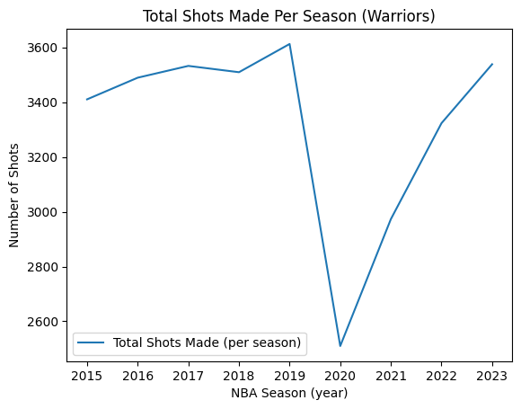

```python
year = ['2015', '2016', '2017', '2018', '2019', '2020', '2021', '2022', '2023']

plt.plot(year, df_2015_2023_Warriors_SUM['fgm'], label = 'Total Shots Made (per season)')
plt.xlabel('NBA Season (year)')
plt.ylabel('Number of Shots')

# displaying the title
plt.title("Total Shots Made Per Season (Warriors)")
plt.legend(loc = 'best')

plt.show()
```

From the Total Shots Made Per Season (Warriors) and Total 2's/3's Made Per Season (Warriors) plots, we can see that in 2020, there is a dip in number of shots made during the 2020 season. However, as the NBA recovered from the effects of COVID-19, we can see numbers start to rise again.

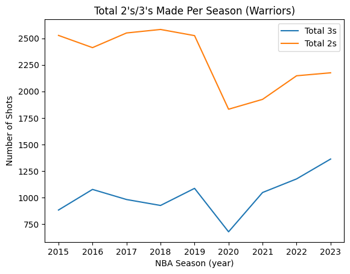

```python
plt.plot(year, df_2015_2023_Warriors_SUM['fg3m'], label = 'Total 3s')
plt.plot(year, df_2015_2023_Warriors_SUM['fg2m'], label = 'Total 2s')

plt.xlabel('NBA Season (year)')
plt.ylabel('Number of Shots')

# displaying the title
plt.title("Total 2's/3's Made Per Season (Warriors)")
plt.legend(loc = 'best')

plt.show()
```

Because NBA teams are at the top of their game, pressure is another important aspect that affects a player/teams' performance. Let us see if there is a significant relationship betweeen the outcome of the game (Win or Loss) and the location at which the Warriors play (Home or Away).

#### **Apply Hypothesis Testing - Home/Away Game Impact on Outcome (Win/Loss) for Warriors**

Determine whether playing at Home vs. Away impacts the Warriors' performance (Win/Loss) from 2015-2023.

**HO:** There is no association between the game's location (Home/Away) and the game's outcome (Win/Loss).

**HA:** There is an association between the game's location and the game's outcome.

**Assume that the alpha value is 0.05**

```python
grouped_data = df_nba_data[(df_nba_data['nameTeam'] == 'Golden State Warriors') & (df_nba_data['yearSeason'] >= 2015) & (df_nba_data['yearSeason'] <= 2023)]

grouped_data = grouped_data.groupby(['nameTeam', 'locationGame', 'outcomeGame']).size().reset_index(name='count')

grouped_data
```

|  | nameTeam | locationGame | outcomeGame | count |
| --- | --- | --- | --- | --- |
| 0 | Golden State Warriors | A | L | 1611 |
| 1 | Golden State Warriors | A | W | 2282 |
| 2 | Golden State Warriors | H | L | 937 |
| 3 | Golden State Warriors | H | W | 3058 |

To do so, we are going to conduct a Chi-Squared test to determine if there is a relationship between the location the Warriors plays at (Home or Away) and whether they win (Win or Loss).

First, let's print out a contingency table showing this relationship.

```python
from scipy.stats import chi2_contingency

# Create contingency table
contingency_table = pd.crosstab(grouped_data['locationGame'], grouped_data['outcomeGame'])

contingency_table
```

| outcomeGame locationGame | L | W |
| --- | --- | --- |
| A | 1 | 1 |
| H | 1 | 1 |

```python
# Perform Chi-Squared Test and calculate p_value
chi2, p_value, _, _ = chi2_contingency(contingency_table)
```

After performing chi-squared test, we are going to print out chi2_value and p_value.

```python
print("p-value: " + str(p_value))
print("chi2-value: " + str(chi2))
```

```
p-value: 1.0
chi2-value: 0.0
```

p-value = 1.0, chi2-value = 0.0

#### **NBA Teams Excluding Warriors**

Now, we are going to do the same analysis for the combination of all other NBA teams - excluding the Warriors from 2015-2023.

Like before, we are going to focus on seasonal trends to understand statistical change over time. Let's look at the sum of:

- field goal makes (2's, 3's, free throws, total)
- field goal attempts (2's, 3's, free throws, total)
- offensive, defensive, total rebounds
- assists
- steals
- blocks
- turnovers
- personal fouls
- points

over the course of each season 2015-2023.

Here is the statistics of the NBA teams excluding the Warriors. There is a lot of data to look through, so we are going to average each category by year.

```python
# NBA teams excluding the Warriors
df_no_warriors = df_nba_data[(df_nba_data['nameTeam'] != 'Golden State Warriors')]

stats = ['yearSeason', 'nameTeam', 'fgm', 'fga', 'fg3m', 'fg3a',
         'fg2m', 'fg2a', 'ftm', 'fta', 'oreb', 'dreb',
         'treb', 'ast', 'stl', 'blk', 'tov', 'pf', 'pts']

df_nba_data_STATS = pd.DataFrame(df_no_warriors, columns=stats)

df_nba_data_SUM = df_nba_data_STATS.groupby(['nameTeam', 'yearSeason']).sum()

df_nba_data_SUM
```

| nameTeam | yearSeason | fgm | fga | fg3m | fg3a | fg2m | fg2a | ftm | fta | oreb | dreb | treb | ast | stl | blk | tov | pf | pts |
| --- | --- | --- | --- | --- | --- | --- | --- | --- | --- | --- | --- | --- | --- | --- | --- | --- | --- | --- |
| Atlanta Hawks | 2015 | 3121 | 6699 | 818 | 2152 | 2303 | 4547 | 1349 | 1735 | 715 | 2611 | 3326 | 2111 | 744 | 380 | 1103 | 1457 | 8409 |
|  | 2016 | 3168 | 6923 | 815 | 2326 | 2353 | 4597 | 1282 | 1638 | 679 | 2772 | 3451 | 2100 | 747 | 486 | 1191 | 1570 | 8433 |
|  | 2017 | 3123 | 6918 | 729 | 2137 | 2394 | 4781 | 1484 | 2039 | 842 | 2793 | 3635 | 1938 | 672 | 397 | 1249 | 1491 | 8459 |
|  | 2018 | 3130 | 7015 | 917 | 2544 | 2213 | 4471 | 1298 | 1654 | 743 | 2693 | 3436 | 1946 | 638 | 348 | 1228 | 1606 | 8475 |
|  | 2019 | 3392 | 7524 | 1067 | 3034 | 2325 | 4490 | 1443 | 1918 | 955 | 2825 | 3780 | 2118 | 675 | 419 | 1363 | 1932 | 9294 |
| ... | ... | ... | ... | ... | ... | ... | ... | ... | ... | ... | ... | ... | ... | ... | ... | ... | ... | ... |
| Washington Wizards | 2019 | 3456 | 7387 | 930 | 2731 | 2526 | 4656 | 1508 | 1963 | 794 | 2679 | 3473 | 2154 | 683 | 379 | 1120 | 1701 | 9350 |
|  | 2020 | 2990 | 6544 | 864 | 2345 | 2126 | 4199 | 1394 | 1770 | 732 | 2295 | 3027 | 1801 | 574 | 309 | 975 | 1634 | 8238 |
|  | 2021 | 3108 | 6547 | 733 | 2088 | 2375 | 4459 | 1449 | 1884 | 697 | 2557 | 3254 | 1835 | 528 | 297 | 1003 | 1555 | 8398 |
|  | 2022 | 3327 | 7056 | 860 | 2512 | 2467 | 4544 | 1393 | 1778 | 737 | 2798 | 3535 | 2052 | 522 | 406 | 1037 | 1545 | 8907 |
|  | 2023 | 3456 | 7127 | 925 | 2601 | 2531 | 4526 | 1442 | 1838 | 774 | 2804 | 3578 | 2083 | 561 | 424 | 1094 | 1539 | 9279 |

261 rows × 17 columns

```python
# Added a year column, so we can groupby the statistics by year.

df_nba_data_SUM = df_nba_data_SUM.assign(year = year*29)

df_nba_data_SUM
```

| nameTeam | yearSeason | fgm | fga | fg3m | fg3a | fg2m | fg2a | ftm | fta | oreb | dreb | treb | ast | stl | blk | tov | pf | pts | year |
| --- | --- | --- | --- | --- | --- | --- | --- | --- | --- | --- | --- | --- | --- | --- | --- | --- | --- | --- | --- |
| Atlanta Hawks | 2015 | 3121 | 6699 | 818 | 2152 | 2303 | 4547 | 1349 | 1735 | 715 | 2611 | 3326 | 2111 | 744 | 380 | 1103 | 1457 | 8409 | 2015 |
|  | 2016 | 3168 | 6923 | 815 | 2326 | 2353 | 4597 | 1282 | 1638 | 679 | 2772 | 3451 | 2100 | 747 | 486 | 1191 | 1570 | 8433 | 2016 |
|  | 2017 | 3123 | 6918 | 729 | 2137 | 2394 | 4781 | 1484 | 2039 | 842 | 2793 | 3635 | 1938 | 672 | 397 | 1249 | 1491 | 8459 | 2017 |
|  | 2018 | 3130 | 7015 | 917 | 2544 | 2213 | 4471 | 1298 | 1654 | 743 | 2693 | 3436 | 1946 | 638 | 348 | 1228 | 1606 | 8475 | 2018 |
|  | 2019 | 3392 | 7524 | 1067 | 3034 | 2325 | 4490 | 1443 | 1918 | 955 | 2825 | 3780 | 2118 | 675 | 419 | 1363 | 1932 | 9294 | 2019 |
| ... | ... | ... | ... | ... | ... | ... | ... | ... | ... | ... | ... | ... | ... | ... | ... | ... | ... | ... | ... |
| Washington Wizards | 2019 | 3456 | 7387 | 930 | 2731 | 2526 | 4656 | 1508 | 1963 | 794 | 2679 | 3473 | 2154 | 683 | 379 | 1120 | 1701 | 9350 | 2019 |
|  | 2020 | 2990 | 6544 | 864 | 2345 | 2126 | 4199 | 1394 | 1770 | 732 | 2295 | 3027 | 1801 | 574 | 309 | 975 | 1634 | 8238 | 2020 |
|  | 2021 | 3108 | 6547 | 733 | 2088 | 2375 | 4459 | 1449 | 1884 | 697 | 2557 | 3254 | 1835 | 528 | 297 | 1003 | 1555 | 8398 | 2021 |
|  | 2022 | 3327 | 7056 | 860 | 2512 | 2467 | 4544 | 1393 | 1778 | 737 | 2798 | 3535 | 2052 | 522 | 406 | 1037 | 1545 | 8907 | 2022 |
|  | 2023 | 3456 | 7127 | 925 | 2601 | 2531 | 4526 | 1442 | 1838 | 774 | 2804 | 3578 | 2083 | 561 | 424 | 1094 | 1539 | 9279 | 2023 |

261 rows × 18 columns

```python
# Let's average all columns over each season

df_nba_data_AVG = df_nba_data_SUM.groupby('year').mean()

df_nba_data_AVG
```

| year | fgm | fga | fg3m | fg3a | fg2m | fg2a | ftm | fta | oreb | dreb | treb | ast | stl | blk | tov | pf | pts |
| --- | --- | --- | --- | --- | --- | --- | --- | --- | --- | --- | --- | --- | --- | --- | --- | --- | --- |
| 2015 | 3061.724138 | 6840.068966 | 634.034483 | 1824.413793 | 2427.689655 | 5015.655172 | 1409.310345 | 1881.862069 | 891.896552 | 2652.586207 | 3544.482759 | 1786.068966 | 632.344828 | 391.448276 | 1124.758621 | 1658.517241 | 8166.793103 |
| 2016 | 3126.793103 | 6929.344828 | 686.896552 | 1955.310345 | 2439.896552 | 4974.034483 | 1455.827586 | 1919.137931 | 856.034483 | 2728.000000 | 3584.034483 | 1808.034483 | 638.517241 | 399.379310 | 1128.379310 | 1656.310345 | 8396.310345 |
| 2017 | 3192.724138 | 7005.448276 | 782.827586 | 2200.344828 | 2409.896552 | 4805.103448 | 1461.931034 | 1895.586207 | 836.551724 | 2731.448276 | 3568.000000 | 1832.862069 | 626.931034 | 384.103448 | 1098.172414 | 1633.689655 | 8630.206897 |
| 2018 | 3241.655172 | 7065.586207 | 859.482759 | 2375.586207 | 2382.172414 | 4690.000000 | 1373.793103 | 1789.724138 | 798.724138 | 2774.206897 | 3572.931034 | 1893.068966 | 629.655172 | 387.793103 | 1116.793103 | 1638.103448 | 8716.586207 |
| 2019 | 3346.827586 | 7287.724138 | 929.034483 | 2627.931034 | 2417.793103 | 4659.793103 | 1441.379310 | 1884.137931 | 849.241379 | 2841.068966 | 3690.310345 | 1993.379310 | 624.275862 | 400.448276 | 1104.551724 | 1701.689655 | 9064.068966 |
| 2020 | 2898.517241 | 6282.862069 | 872.965517 | 2424.413793 | 2025.551724 | 3858.448276 | 1250.965517 | 1618.103448 | 710.482759 | 2459.172414 | 3169.655172 | 1725.310345 | 540.137931 | 346.068966 | 980.517241 | 1465.137931 | 7920.965517 |
| 2021 | 2976.655172 | 6398.758621 | 910.310345 | 2494.379310 | 2066.344828 | 3904.379310 | 1226.413793 | 1580.482759 | 714.724138 | 2492.724138 | 3207.448276 | 1786.172414 | 547.172414 | 354.931034 | 954.758621 | 1389.241379 | 8090.034483 |
| 2022 | 3334.206897 | 7224.965517 | 1014.344828 | 2870.241379 | 2319.862069 | 4354.724138 | 1401.275862 | 1809.379310 | 850.965517 | 2788.862069 | 3639.827586 | 2013.896552 | 621.551724 | 385.517241 | 1068.448276 | 1608.724138 | 9084.034483 |
| 2023 | 3433.793103 | 7227.482759 | 992.482759 | 2761.793103 | 2441.310345 | 4465.689655 | 1512.724138 | 1942.448276 | 854.689655 | 2702.241379 | 3556.931034 | 2065.689655 | 600.172414 | 385.172414 | 1090.000000 | 1639.413793 | 9372.793103 |

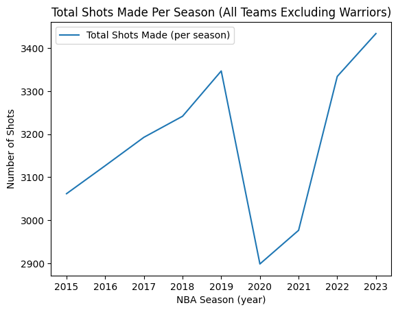

```python
plt.plot(year, df_nba_data_AVG['fgm'], label = 'Total Shots Made (per season)')
plt.xlabel('NBA Season (year)')
plt.ylabel('Number of Shots')

# displaying the title
plt.title("Total Shots Made Per Season (All Teams Excluding Warriors)")
plt.legend(loc = 'best')

plt.show()
```

Just like with the Warriors, on average, the rest of the NBA teams also experienced a drop in statistics around 2020 (during the COVID-19 pandemic). Generally, the statistics seem to be improving over time.

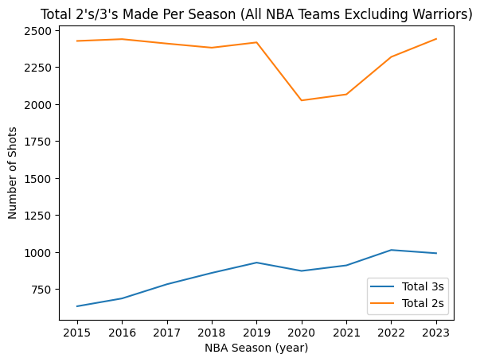

```python
plt.plot(year, df_nba_data_AVG['fg3m'], label = 'Total 3s')
plt.plot(year, df_nba_data_AVG['fg2m'], label = 'Total 2s')

plt.xlabel('NBA Season (year)')
plt.ylabel('Number of Shots')

# displaying the title
plt.title("Total 2's/3's Made Per Season (All NBA Teams Excluding Warriors)")
plt.legend(loc = 'best')

plt.show()
```

#### **Any Relationships?**

Now that we have looked at the data for the Warriors and NBA Teams (excluding the Warriors) separately, we want to explore any relationships between the two.

First, let's see if there is an statistically important relationships between the Warriors stat and the rest of the teams. Rather than focusing on every statistics, we are going to explore a few.

#### **Apply Hypothesis Testing - Total Made 3's in 2015-2023**

Determine if there is a significant difference in the number of 3's that the Warriors made vs. other teams. We are curious to look at this statistic because the Warriors are known for their 3-point shooting and having that as a part of their game plan. They have one of the best 3-point shooters on their team: Stephen Curry.

**HO:** There are no significant differences in the number of 3's made between the Warriors and all other NBA teams from 2015-23.

**HA:** There are significant differences in the number of 3's made between groups from 2015-23.

**Assume that the alpha value is 0.05**

Conduct a z-test to determine if there is a relationship for the number of 3's made between the Warriors and all other NBA teams from 2015-23.

```python
from statsmodels.stats.weightstats import ztest

# Perform the z-test
z_val, p_value = ztest(df_2015_2023_Warriors_SUM['fg3m'], df_nba_data_AVG['fg3m'])

print(z_val, p_value)
```

```
2.2061496021029527 0.027373526663665635
```

The z-test test yields a low p-value (0.027), less than 0.05, which indicates that there is a significant difference in the number of 3's made between the two groups in the 2015-2023 seasons. The z-value explains the strength of the statistical evidence against the null hypothesis. Because our z-value is slightly high and the p-value < 0.05, there is good statistical evidence against the null, which indicates that there is a significant different in number of 3's made from 2015-23.

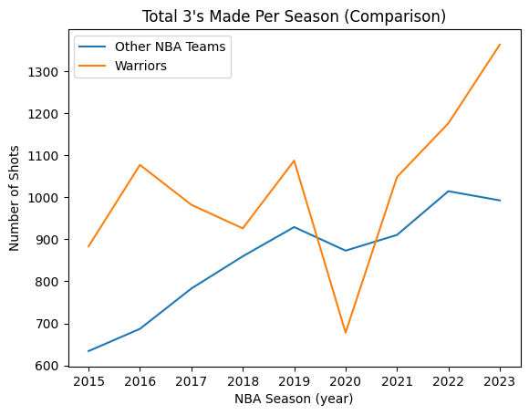

```python
plt.plot(year, df_nba_data_AVG['fg3m'], label = 'Other NBA Teams')
plt.plot(year, df_2015_2023_Warriors_SUM['fg3m'], label = 'Warriors')

plt.xlabel('NBA Season (year)')
plt.ylabel('Number of Shots')

# displaying the title
plt.title("Total 3's Made Per Season (Comparison)")
plt.legend(loc = 'best')

plt.show()
```

Based off of the hypothesis test (specifically z-test) and the graph, there is a significant difference in threes made. Although there is lots of fluctuation during the period of COVID-19, if we look at 2015 and 2023, which we can assume are more unaffected seasons, there is a huge difference between groups. It is important to note that the Warriors are known for taking a lot of 3-pointers during the game, so it's not a huge surprise that their numbers outweigh other NBA teams. However, this could be an interesting factor to consider when looking at successful NBA teams and strategy. Because 3's are the highest point baskets in the game (excluding +1 plays from fouls), this could be an important skill set to improve upon to be competitive against the Warriors. Overall, we can see an upwards trend in 3-pointers. A focus on 3-point shots has arguably [revolutionized](https://www.nba.com/news/3-point-era-nba-75) and changed the game of basketball.

#### **2015**

In 2015, the average number of 3-point shots made by all NBA teams (excluding the Warriors) was around **634** shots. For the Warriors in 2015, the average number of 3's made was **883**. That is a 249 shot difference or **747 point difference**!

#### **2023**

During last season (2023), the average number of 3's made by all teams but the Warriors was around **992** shots. For the Warriors, the average number of 3-point shots made was **1363**. That is a 371 shot difference or **1,113 point difference**!

There could be something said here about the importance of 3-pointers in the game because of it's high point value. Threes made can impact the score of the game quickly and has shown to be a successful factor, especially for the Warriors.

#### **Apply Hypothesis Testing - Total Assists in 2015-2023**

Determine if there is a significant difference in the number of assists that the Warriors made vs. other teams. Because basketball is not a one-player game, we want to understand how the number of team assists affects the game and if assisting more leads to better play.

**HO:** There are no significant differences in the number of assists made between the Warriors and all other NBA teams from 2015-23.

**HA:** There are significant differences in the number of assists made between groups from 2015-23.

**Assume that the alpha value is 0.05**

Conducting a z-test to determine if there is a relationship for the number of assists between the Warriors and all other NBA teams from 2015-23.

```python
# Perform the z-test
z_val, p_value = ztest(df_2015_2023_Warriors_SUM['ast'], df_nba_data_AVG['ast'])

print(z_val, p_value)
```

```
3.802578112848984 0.0001431980950432484
```

The z-test test yields a low p-value (0.000143) < 0.05, which indicates that there is a significant difference in the number of assists made between the two groups in the 2015-2023 seasons. The z-value explains the strength of the statistical evidence against the null hypothesis. Because our z-value is slightly high and the p-value < 0.05, there is good statistical evidence against the null, which indicates that there is a significant different in number of assists made from 2015-23.

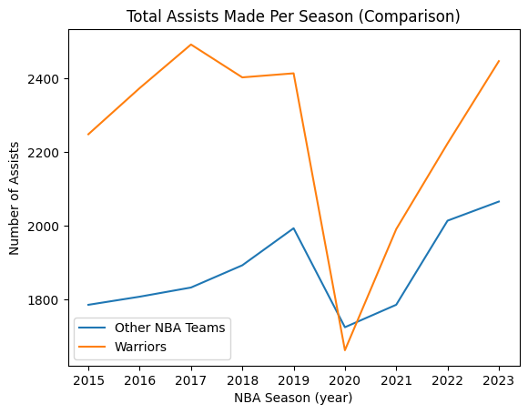

```python
plt.plot(year, df_nba_data_AVG['ast'], label = 'Other NBA Teams')
plt.plot(year, df_2015_2023_Warriors_SUM['ast'], label = 'Warriors')

plt.xlabel('NBA Season (year)')
plt.ylabel('Number of Assists')

# displaying the title
plt.title("Total Assists Made Per Season (Comparison)")
plt.legend(loc = 'best')

plt.show()
```

Looking at the assist numbers and the results of the z-test, there is a clear difference between the two groups. The Warriors have a much higher number of assists than other teams, excluding the COVID-19 years. This is understandable because passing is important to get open threes. Because the Warriors focus on 3-point shots, there is a greater emphasis on passing (assisting) to the open player rather than taking a contested shot. It is much more likely for someone to make an open three vs. a contested one. Looking past 3-pointers, assists can lead to more movement on the court and thus more opportunities for open shots. For example, skip passes (passing the ball from one side of the court to the other on offense) or "swinging" the ball (ball movement around the 3-point line) are great ways to shuffle the defense to hopefully create an open offensive player. Assisting and being playmakers for each other on the court may be an area to look into for being a successful team.

#### **Minnesota Timberwolves**

Let's see how important 3's and assists are to a team's success or if that is determinant on the team's strengths and weaknesses! We are now going to look at the Minnesota Timberwolves. According to [Star Tribune newspaper](https://www.startribune.com/timberwolves-are-getting-serious-for-the-first-time-in-two-decades/600363549/), the Timberwolves have not been a contender since the early 2000's when they made it to the Western Conference Finals. Now, they are back in the playoffs and playing much better than they have for the past two decades.

At least for the Warriors, there is a statistically significant difference between the number of 3's and assists taken by the Warriors compared to other NBA teams. The Warriors have been successful during the period we are analyzing (2015-2023), so we are curious to see if these statistics have helped in the success of up-and-coming teams.

```python
df_timberwolves = df_nba_data[(df_nba_data['nameTeam'] == 'Minnesota Timberwolves')]

df_timberwolves_STATS = pd.DataFrame(df_timberwolves, columns=stats)

df_timberwolves_STATS = df_timberwolves_STATS.groupby('yearSeason').sum()

df_timberwolves_STATS
```

| yearSeason | nameTeam | fgm | fga | fg3m | fg3a | fg2m | fg2a | ftm | fta | oreb | dreb | treb | ast | stl | blk | tov | pf | pts |
| --- | --- | --- | --- | --- | --- | --- | --- | --- | --- | --- | --- | --- | --- | --- | --- | --- | --- | --- |
| 2015 | Minnesota TimberwolvesMinnesota TimberwolvesMi... | 2986 | 6820 | 406 | 1223 | 2580 | 5597 | 1638 | 2110 | 949 | 2406 | 3355 | 1771 | 668 | 327 | 1172 | 1571 | 8016 |
| 2016 | Minnesota TimberwolvesMinnesota TimberwolvesMi... | 3095 | 6668 | 455 | 1347 | 2640 | 5321 | 1753 | 2213 | 821 | 2587 | 3408 | 1916 | 656 | 375 | 1177 | 1696 | 8398 |
| 2017 | Minnesota TimberwolvesMinnesota TimberwolvesMi... | 3235 | 6922 | 601 | 1723 | 2634 | 5199 | 1586 | 1986 | 938 | 2540 | 3478 | 1940 | 654 | 370 | 1099 | 1646 | 8657 |
| 2018 | Minnesota TimberwolvesMinnesota TimberwolvesMi... | 3365 | 7063 | 658 | 1845 | 2707 | 5218 | 1592 | 1980 | 848 | 2593 | 3441 | 1861 | 689 | 345 | 963 | 1495 | 8980 |
| 2019 | Minnesota TimberwolvesMinnesota TimberwolvesMi... | 3413 | 7483 | 827 | 2357 | 2586 | 5126 | 1570 | 1995 | 923 | 2750 | 3673 | 2018 | 683 | 411 | 1030 | 1664 | 9223 |
| 2020 | Minnesota TimberwolvesMinnesota TimberwolvesMi... | 2586 | 5865 | 853 | 2540 | 1733 | 3325 | 1223 | 1624 | 675 | 2193 | 2868 | 1525 | 555 | 362 | 943 | 1370 | 7248 |
| 2021 | Minnesota TimberwolvesMinnesota TimberwolvesMi... | 2932 | 6546 | 944 | 2706 | 1988 | 3840 | 1265 | 1662 | 757 | 2376 | 3133 | 1846 | 632 | 398 | 983 | 1507 | 8073 |
| 2022 | Minnesota TimberwolvesMinnesota TimberwolvesMi... | 3411 | 7458 | 1211 | 3386 | 2200 | 4072 | 1474 | 1894 | 921 | 2700 | 3621 | 2106 | 721 | 460 | 1126 | 1786 | 9507 |
| 2023 | Minnesota TimberwolvesMinnesota TimberwolvesMi... | 3515 | 7167 | 997 | 2731 | 2518 | 4436 | 1467 | 1942 | 749 | 2686 | 3435 | 2145 | 657 | 444 | 1212 | 1768 | 9494 |

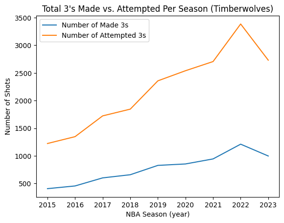

```python
plt.plot(year,df_timberwolves_STATS['fg3m'], label = 'Number of Made 3s')

plt.plot(year,df_timberwolves_STATS['fg3a'], label = 'Number of Attempted 3s')

plt.legend(loc = 'best')

plt.xlabel('NBA Season (year)')
plt.ylabel('Number of Shots')

# displaying the title
plt.title("Total 3's Made vs. Attempted Per Season (Timberwolves)")

plt.show()
```

Looking at the plot above, we can see an increase in number of 3's attempted and made from 2015-2023. Although there is a slight decrease between the 2022 and 2023 seasons, overall there has been an upward trend. This trend has stayed the same even during COVID-19, even though we have seen fluctuations from the Warriors and the average of NBA teams. Because the Timberwolves are doing the best they have in a while, the number of 3's they have made can be considered a factor that contributes to their successes. From the article we linked above, it is argued that the league is moving towards trying to make more 3-point shots. It is important to mention that one category is never the only driving factor into the success of a team. We are not trying to argue that 3-pointers are the only factor into making a great team, but we are analyzing how it could be a factor. The same goes for our analysis on assists. We chose to use these two statistics because we saw interesting trends, but more research must be done in order to get a greater understanding on what makes a great team.

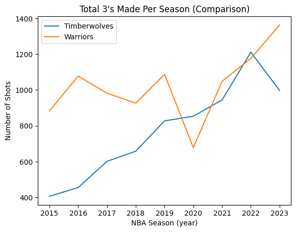

```python
plt.plot(year, df_timberwolves_STATS['fg3m'], label = 'Timberwolves')
plt.plot(year, df_2015_2023_Warriors_SUM['fg3m'], label = 'Warriors')

plt.xlabel('NBA Season (year)')
plt.ylabel('Number of Shots')

# displaying the title
plt.title("Total 3's Made Per Season (Comparison)")
plt.legend(loc = 'best')

plt.show()
```

Comparing the Timberwolves to the Warriors, there is still a difference between the number of 3's made. This is understandable because the Warriors pride themselves on their 3-point shooting abilities. However, whereas the difference between 3's in 2015 is 477 shots, the difference in 2023 is 366. Although the gap is still wide, the Timberwolves have shown upwards trends in making more 3's. This is a significant discovery because 3's could be an important addition to a team's skillsets when considering the success of the team.

Next, we want to look at the trajectory of assists for the Timberwolves from 2015-2023.

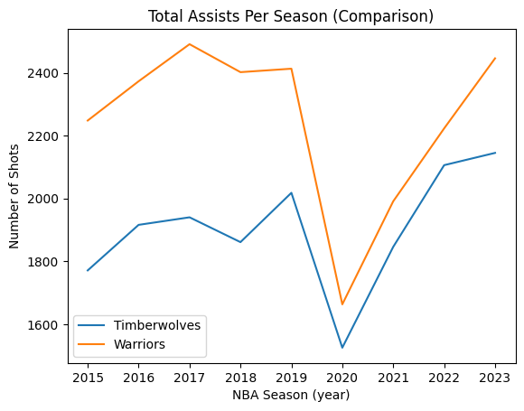

```python
plt.plot(year, df_timberwolves_STATS['ast'], label = 'Timberwolves')
plt.plot(year, df_2015_2023_Warriors_SUM['ast'], label = 'Warriors')

plt.xlabel('NBA Season (year)')
plt.ylabel('Number of Shots')

# displaying the title
plt.title("Total Assists Per Season (Comparison)")
plt.legend(loc = 'best')

plt.show()
```

Interestingly, the Warriors and Timberwolves seem to follow a similar progression in assists from 2015-2023. However after COVID-19, both of their assists have gone up. The upward trend for the Timberwolves could be similar to why the Warriors assist numbers are high because open 3's are easier to make than contested ones. Thus, it is more likely that a player will pass to another for an open 3. However that is only one of numerous reasons why assist numbers went up.

#### **Detroit Pistons**

We have just analyzed the Minnesota Timberwolves, a team who may have a bright future ahead of them. However, we are going to shift our focus to a team whose performance has been historically poor and who has not won a championship since 2004. In the 2023 season, the Piston's record was 17-65 and this year, their record is worse at 14-68. According to [The Guardian](https://www.theguardian.com/sport/2023/dec/27/detroit-pistons-nba-worst-team-league-record-defeats), the Pistons have suffered from faulty roster-building and have not proved to be one other than one of the worst teams ever. We are going to analyze why this is the case during the 2015-2023 seasons based on the two statistics we have focused on thus far: 3's and assists.

```python
df_pistons = df_nba_data[(df_nba_data['nameTeam'] == 'Detroit Pistons')]

df_pistons_STATS = pd.DataFrame(df_pistons, columns=stats)

df_pistons_STATS = df_pistons_STATS.groupby('yearSeason').sum()

df_pistons_STATS
```

| yearSeason | nameTeam | fgm | fga | fg3m | fg3a | fg2m | fg2a | ftm | fta | oreb | dreb | treb | ast | stl | blk | tov | pf | pts |
| --- | --- | --- | --- | --- | --- | --- | --- | --- | --- | --- | --- | --- | --- | --- | --- | --- | --- | --- |
| 2015 | Detroit PistonsDetroit PistonsDetroit PistonsD... | 3041 | 7038 | 703 | 2043 | 2338 | 4995 | 1292 | 1838 | 1051 | 2630 | 3681 | 1771 | 623 | 383 | 1037 | 1559 | 8077 |
| 2016 | Detroit PistonsDetroit PistonsDetroit PistonsD... | 3111 | 7087 | 740 | 2148 | 2371 | 4939 | 1399 | 2095 | 1021 | 2777 | 3798 | 1594 | 573 | 304 | 1063 | 1557 | 8361 |
| 2017 | Detroit PistonsDetroit PistonsDetroit PistonsD... | 3269 | 7282 | 631 | 1915 | 2638 | 5367 | 1140 | 1586 | 908 | 2838 | 3746 | 1732 | 574 | 310 | 932 | 1467 | 8309 |
| 2018 | Detroit PistonsDetroit PistonsDetroit PistonsD... | 3208 | 7129 | 886 | 2373 | 2322 | 4756 | 1207 | 1621 | 830 | 2756 | 3586 | 1868 | 628 | 317 | 1045 | 1508 | 8509 |
| 2019 | Detroit PistonsDetroit PistonsDetroit PistonsD... | 3185 | 7238 | 993 | 2854 | 2192 | 4384 | 1415 | 1893 | 936 | 2752 | 3688 | 1845 | 569 | 331 | 1062 | 1811 | 8778 |
| 2020 | Detroit PistonsDetroit PistonsDetroit PistonsD... | 2595 | 5658 | 791 | 2157 | 1804 | 3501 | 1097 | 1476 | 644 | 2109 | 2753 | 1589 | 490 | 299 | 960 | 1299 | 7078 |
| 2021 | Detroit PistonsDetroit PistonsDetroit PistonsD... | 2783 | 6162 | 832 | 2370 | 1951 | 3792 | 1278 | 1683 | 694 | 2381 | 3075 | 1743 | 531 | 371 | 1020 | 1477 | 7676 |
| 2022 | Detroit PistonsDetroit PistonsDetroit PistonsD... | 3129 | 7267 | 925 | 2838 | 2204 | 4429 | 1413 | 1806 | 900 | 2625 | 3525 | 1924 | 630 | 393 | 1098 | 1799 | 8596 |
| 2023 | Detroit PistonsDetroit PistonsDetroit PistonsD... | 3244 | 7140 | 934 | 2659 | 2310 | 4481 | 1623 | 2106 | 916 | 2564 | 3480 | 1884 | 574 | 308 | 1189 | 1813 | 9045 |

#### **Apply Hypothesis Testing - Total Made 3's in 2015-2023 (Timberwolves vs. Pistons)**

Determine if there is a significant difference in the number of 3's that the Timberwolves made vs. Pistons. We are curious to look at this statistic because the Timberwolves may be turning a corner in their play, while the Pistons have yet to show any improvement in the last few seasons with the worst record for the past 2 seasons.

**HO:** There are no significant differences in the number of 3's made between the Timberwolves and Pistons from 2015-23.

**HA:** There are significant differences in the number of 3's made between the Timberwolves and Pistons from 2015-23.

**Assume that the alpha value is 0.05**

Conducting a z-test to determine if there is a relationship for the number of 3's made between the Timberwolves and Pistons from 2015-23.

```python
# Perform the z-test
z_val, p_value = ztest(df_pistons_STATS['fg3m'], df_timberwolves_STATS['fg3m'])

print(p_value)
```

```
0.5791039961606893
```

The z-test test yields a high p-value (0.58), > 0.05, which indicates that there is not a significant difference in the number of 3's made between the Timberwolves and Pistons in the 2015-2023 seasons. Thus, we fail to reject the null hypothesis, meaning that there are no significant differences in the number of 3's made between the Timberwolves and Pistons from 2015-23. This is interesting because the Pistons have similar 3-point statistics to the Timberwolves. This is a great reminder to show that one statistic is not the only factor into a team's successes. Although the Timberwolves are more successful than the Pistons this season, there was not a statistically significant difference when the z-test was used. Thus, the Pistons must be lacking in other areas, which does not create a well-rounded team.

Below, we have plotted the total 3's made per season from 2015-2023 for the Pistons and Timberwolves.

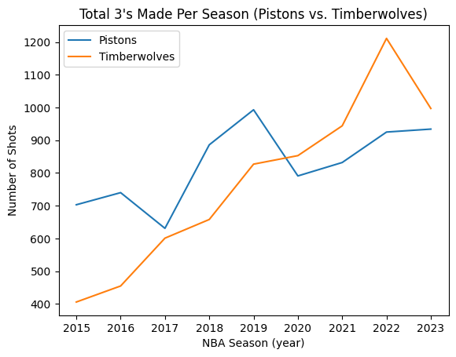

```python
plt.plot(year, df_pistons_STATS['fg3m'], label = 'Pistons')
plt.plot(year, df_timberwolves_STATS['fg3m'], label = 'Timberwolves')

plt.xlabel('NBA Season (year)')
plt.ylabel('Number of Shots')

# displaying the title
plt.title("Total 3's Made Per Season (Pistons vs. Timberwolves)")
plt.legend(loc = 'best')

plt.show()
```

#### **Apply Hypothesis Testing - Total Assists in 2015-2023**

Determine if there is a significant difference in the number of assists between the Timberwolves and Pistons. We noticed a large difference between the number of assists between Warriors and other NBA teams, so we wanted to see the relationship of assists over time.

**HO:** There are no significant differences in the number of assists made between the Timberwolves and Pistons from 2015-23.

**HA:** There are significant differences in the number of assists made between the Timberwolves and Pistons from 2015-23.

**Assume that the alpha value is 0.05**

Conducting a z-test to determine if there is a relationship for the number of assists between the Timberwolves and Pistons from 2015-23.

```python
# Perform the z-test
z_val, p_value = ztest(df_timberwolves_STATS['ast'], df_pistons_STATS['ast'])

print(p_value)
```

```
0.07820320540252793
```

The z-test test yields a high p-value (0.0.078) > 0.05, which highlights that there is not a significant difference and we fail to reject the null hypothesis. By failing to reject HO, we determine that there is no significant differences in the number of assists made between the Timberwolves and Pistons from 2015-23. Again, like with testing 3-point shooting between the two teams, we cannot only rely on one factor to impact how the team plays. Although the Pistons have similar assist numbers and made 3's to the Timberwolves, there must be other factors that are impacting the team's performance. Additionally, we cannot assume that assists and 3's are what makes the Timberwolves successful. We chose to focus on these two statistics because we saw that these stats play an important role to the Warrior's performance compared to the average of other NBA teams. The Warrior's have been a dominant team for a while, and we were curious to see why that was. For the Warriors, it has been seen through watching their games and this analysis that one of their main strengths is 3-pointers. However, because that strategy works for the Warriors, another strategy can always work better for a different team.

### **5. Using Machine Learning in NBA Player Data Analysis**

The NBA has vast amounts of data every season, which is a valuable resource for teams, analysts, and fans who seek to understand the game at a deeper level. Using Machine Learning tools and strategies in the analysis of NBA player data offers a transformative approach to interpreting this complex dataset. Machine Learning models can offer new insights into player performances and dynamics within the NBA. By focusing on specific features such as field goals attempted, three-point attempts, assists, and other player stats, this analysis will not only predict the points a player might score in a game but also reveal how these factors correlate with overall player and team success.

If we want to look at the NBA data in a more genralized way, we can start by analyzing player points per games. The machine learning models used in this section offer a way to make more precise and insightful forecasts based on comprehensive player data.

#### **Predicting Player Points Using Linear Regression**

We can use a simple linear regression model to predict the points a player will score in a game based on their field goals attempted, three-point attempts, and assists. This will provide us with valuable insights into the factors that most influence a player's scoring in a game.

```python
from sklearn.model_selection import train_test_split
from sklearn.linear_model import LinearRegression
from sklearn.metrics import mean_squared_error
import numpy as np

features = df_main_data[['fga', 'fg3a', 'ast']]
target = df_main_data['pts']

X_train, X_test, y_train, y_test = train_test_split(features, target, test_size=0.2, random_state=42)

model = LinearRegression()
model.fit(X_train, y_train)

predictions = model.predict(X_test)
mse = mean_squared_error(y_test, predictions)
rmse = np.sqrt(mse)

print(predictions)
```

```
[ 7.26919012  6.05959891  2.25457525 ...  5.9921181   8.6323874
 15.0550364 ]
```

```python
print(f"Root Mean Squared Error: {rmse:.2f}")
```

```
Root Mean Squared Error: 3.86
```

Here, the predictions variable represents the predicted number of points scored by players in each instance of the test dataset based on the input features (field goals attempted, three-point attempts, and assists). These are believed to influence the points scored by a player.

Each number in the array is the predicted score for an individual player in a specific game. For example, the first number, 7.26919012, suggests that the model predicts the player will score approximately 7.27 points in that game.

By comparing these predictions to the actual scores, we can calculate the RMSE to quantify the average error in the predictions. The RMSE value is a measure of the model's accuracy, indicating the average deviation of the predicted points from the actual points scored by the players. An RMSE value means that, on average, the model's predictions are about 3.86 points away from the actual scoring outcomes. This value suggests that the model is reasonably accurate in predicting player scores, but there is still some variability that isn't captured by the model.

Now, let's say we want to determine the most significant factor contributing to the predicted player scores in our linear regression model. We can do this by examining the coefficients of the model.

```python
coefficients = model.coef_
features = ['fga', 'fg3a', 'ast']

for feature, coef in zip(features, coefficients):
    print(f"{feature}: {coef}")
```

```
fga: 1.2433316202533087
fg3a: 0.03374040555331691
ast: 0.05993282692223699
```

These coefficients indicate the relative impact of each feature (field goals attempted, three-point attempts, assists) on the predicted player points. The coefficient of 1.2433 is the highest among the three features. This shows us that the field goals attempted have the most significant impact on predicting a player's points scored. This makes sense, as the number of field goals attempted will definitely impact the total number of points scored. On the other hand, the coefficient of 0.0337 is much smaller, showing that while three-point attempts do contribute to a player's scoring, their impact is relatively minor compared to field goals attempted.

The analysis clearly points to field goals attempted as the key factor in predicting a player's scoring output according to this model. This information and data can be useful when maximizing points through different strategies.

To explain linear regression machine learning models check out this [link](https://www.analyticsvidhya.com/blog/2021/06/linear-regression-in-machine-learning/)

### **Exploring Other Factors that Affect Player Performance using RandomForest Regressor**

We also wanted to incorporate more features to help capture more nuances that affect player performance, specifically the points they score. Using another dataset, containing information such as player's height, weight, age, etc., we were able to analyze the way other attributes can influence playing style and capabilities. For this analysis, we are going to use another dataset containing more information about the players, including their age, height, and weight.

We can start by importing the new dataset and cleaning up the columns and rows, by merging based on the name of the player.

```python
# df_player_data = pd.read_csv('/content/all_seasons.csv')
df_player_data = pd.read_csv('/content/drive/MyDrive/Colab Notebooks/all_seasons.csv')

df_player_data

df_main_data['namePlayer'] = df_main_data['namePlayer'].str.strip().str.lower()
df_player_data['player_name'] = df_player_data['player_name'].str.strip().str.lower()

merged_data = pd.merge(df_main_data, df_player_data, left_on='namePlayer', right_on='player_name', how='inner')

merged_data['namePlayer'] = merged_data['namePlayer'].str.title()

merged_data
```

|  | yearSeason | slugSeason | slugLeague | typeSeason | dateGame | idGame | numberGameTeamSeason | nameTeam | idTeam | isB2B | ... | pts_y | reb | ast_y | net_rating | oreb_pct | dreb_pct | usg_pct | ts_pct | ast_pct | season |
| --- | --- | --- | --- | --- | --- | --- | --- | --- | --- | --- | --- | --- | --- | --- | --- | --- | --- | --- | --- | --- | --- |
| 0 | 2010 | 2009-10 | NBA | Regular Season | 2009-10-27 | 20900004 | 1 | Los Angeles Clippers | 1610612746 | 0 | ... | 16.1 | 2.6 | 2.8 | -9.0 | 0.019 | 0.070 | 0.208 | 0.593 | 0.137 | 2008-09 |
| 1 | 2010 | 2009-10 | NBA | Regular Season | 2009-10-27 | 20900004 | 1 | Los Angeles Clippers | 1610612746 | 0 | ... | 16.9 | 2.6 | 3.0 | -4.6 | 0.013 | 0.070 | 0.214 | 0.571 | 0.135 | 2009-10 |
| 2 | 2010 | 2009-10 | NBA | Regular Season | 2009-10-27 | 20900004 | 1 | Los Angeles Clippers | 1610612746 | 0 | ... | 22.3 | 2.9 | 4.4 | -1.7 | 0.025 | 0.064 | 0.262 | 0.566 | 0.197 | 2010-11 |
| 3 | 2010 | 2009-10 | NBA | Regular Season | 2009-10-27 | 20900004 | 1 | Los Angeles Clippers | 1610612746 | 0 | ... | 20.6 | 2.8 | 3.4 | 5.2 | 0.008 | 0.088 | 0.289 | 0.549 | 0.172 | 2011-12 |
| 4 | 2010 | 2009-10 | NBA | Regular Season | 2009-10-27 | 20900004 | 1 | Los Angeles Clippers | 1610612746 | 0 | ... | 17.0 | 1.8 | 3.3 | -2.8 | 0.009 | 0.064 | 0.284 | 0.523 | 0.183 | 2012-13 |
| ... | ... | ... | ... | ... | ... | ... | ... | ... | ... | ... | ... | ... | ... | ... | ... | ... | ... | ... | ... | ... | ... |
| 3267734 | 2023 | 2022-23 | NBA | Regular Season | 2023-04-04 | 22201182 | 79 | Atlanta Hawks | 1610612737 | 0 | ... | 2.0 | 1.0 | 0.0 | 60.0 | 0.000 | 0.400 | 0.385 | 0.400 | 0.000 | 2022-23 |
| 3267735 | 2023 | 2022-23 | NBA | Regular Season | 2023-04-09 | 22201216 | 82 | Atlanta Hawks | 1610612737 | 0 | ... | 2.0 | 1.0 | 0.0 | 60.0 | 0.000 | 0.400 | 0.385 | 0.400 | 0.000 | 2022-23 |
| 3267736 | 2023 | 2022-23 | NBA | Regular Season | 2023-04-09 | 22201217 | 82 | Brooklyn Nets | 1610612751 | 0 | ... | 16.0 | 9.0 | 7.0 | -17.5 | 0.075 | 0.176 | 0.205 | 0.621 | 0.350 | 2022-23 |
| 3267737 | 2023 | 2022-23 | NBA | Regular Season | 2023-04-09 | 22201226 | 82 | Memphis Grizzlies | 1610612763 | 0 | ... | 3.0 | 4.0 | 7.0 | -14.9 | 0.000 | 0.095 | 0.052 | 0.500 | 0.212 | 2022-23 |
| 3267738 | 2023 | 2022-23 | NBA | Regular Season | 2023-04-09 | 22201230 | 82 | Portland Trail Blazers | 1610612757 | 0 | ... | 7.0 | 3.0 | 0.0 | -68.1 | 0.080 | 0.067 | 0.140 | 0.518 | 0.000 | 2022-23 |

3267739 rows × 80 columns

```python
filtered_data = merged_data[['namePlayer', 'player_height', 'player_weight', 'fga', 'fg3a', 'age', 'pts_x']]
filtered_data
```

|  | namePlayer | player_height | player_weight | fga | fg3a | age | pts_x |
| --- | --- | --- | --- | --- | --- | --- | --- |
| 0 | Eric Gordon | 190.50 | 100.697424 | 14 | 5 | 20.0 | 21 |
| 1 | Eric Gordon | 190.50 | 100.697424 | 14 | 5 | 21.0 | 21 |
| 2 | Eric Gordon | 190.50 | 97.522280 | 14 | 5 | 22.0 | 21 |
| 3 | Eric Gordon | 190.50 | 97.522280 | 14 | 5 | 23.0 | 21 |
| 4 | Eric Gordon | 190.50 | 97.522280 | 14 | 5 | 24.0 | 21 |
| ... | ... | ... | ... | ... | ... | ... | ... |
| 3267734 | Donovan Williams | 198.12 | 86.182480 | 1 | 1 | 21.0 | 0 |
| 3267735 | Donovan Williams | 198.12 | 86.182480 | 4 | 1 | 21.0 | 4 |
| 3267736 | Raiquan Gray | 200.66 | 122.016248 | 12 | 5 | 23.0 | 16 |
| 3267737 | Jacob Gilyard | 175.26 | 72.574720 | 3 | 3 | 24.0 | 3 |
| 3267738 | Chance Comanche | 208.28 | 95.254320 | 5 | 0 | 27.0 | 7 |

3267739 rows × 7 columns

```python
from sklearn.ensemble import RandomForestRegressor
from sklearn.model_selection import train_test_split
from sklearn.metrics import mean_squared_error
import numpy as np

print(filtered_data.columns)
features = merged_data[['fga', 'fg3a', 'player_height', 'player_weight','age']]
target = merged_data['pts_x']

X_train, X_test, y_train, y_test = train_test_split(features, target, test_size=0.2, random_state=42)

model = RandomForestRegressor(n_estimators=100, random_state=42)
model.fit(X_train, y_train)

predictions = model.predict(X_test)
mse = mean_squared_error(y_test, predictions)
rmse = np.sqrt(mse)

print(f"Root Mean Squared Error: {rmse:.2f}")
```

```
Index(['namePlayer', 'player_height', 'player_weight', 'fga', 'fg3a', 'age',
       'pts_x'],
      dtype='object')
Root Mean Squared Error: 4.06
```

The RMSE indicates that the model’s predictions are, on average, off by 4.06 points from the actual points scored by players. In basketball, where player performances can vary significantly from game to game, an RMSE of 4.06 suggests that the model has a moderate level of precision. This level of error can be relatively good depending on the typical scoring range of players. For instance, if players generally score between 10 to 30 points per game, an average error of 4.06 isn't too large.

After training the model, we can extract the feature importances to get more insight into which features are most important for predicting the target variable, in our case the number of points scored. These importances are returned as an array where each element corresponds to a feature in the order they were used in training.

```python
feature_importances = model.feature_importances_
feature_importances
```

```
array([0.90145124, 0.02009056, 0.01829566, 0.02988079, 0.03028175])
```

Our array shows that highest value to be 0.90145124, which corresponds to the field goals attempted by player. The highler values indicate that the feature plays a more significant role in predicting the target variable in the mode. In our context, this makes sense, as the more field goals that are attempted, the more chances the player has to score, thus increasing the number of points.

We can use a bar chart to visualize which features are the most important.

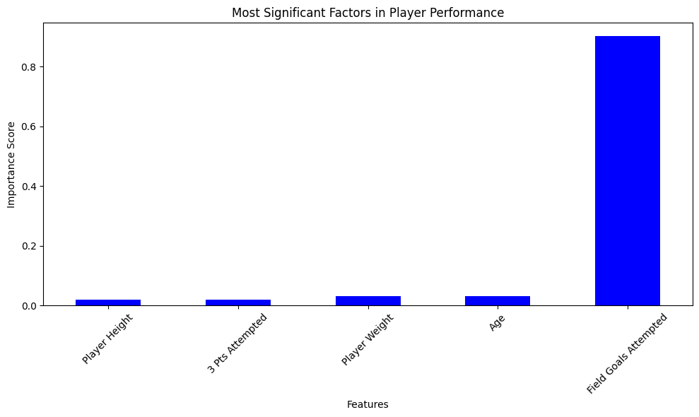

```python
import matplotlib.pyplot as plt
import pandas as pd

importances = pd.Series(feature_importances, index=features.columns)
sorted_importances = importances.sort_values()


x1 = [0,1,2,3,4]
squad = ['Player Height','3 Pts Attempted','Player Weight','Age', 'Field Goals Attempted']



plt.figure(figsize=(10, 6))
sorted_importances.plot(kind='bar', color='blue')
plt.title('Most Significant Factors in Player Performance')
plt.xlabel('Features')
plt.ylabel('Importance Score')
plt.xticks(x1, squad, rotation=45)
plt.tight_layout()
plt.show()
```

To explain random forest regression models check out this [link](https://towardsdatascience.com/random-forest-regression-5f605132d19d)

### **6. Conclusion**

We began our analysis by looking at the Warriors data and the average of other NBA teams to determine which statistics are important to a team's successes. Then, we delved into a comparison in the relationship between these two groups. We saw that the Warriors focused their game on three-pointers and that's how they maintained success throughout the years. We saw that there were statistical differences for 3-pointers and assists, so we focused our analysis on those two categories. Then, we became curious about what makes a great team? We wanted to find a team that may be up-and-coming and one that has not played well. These were the Timberwolves and Pistons, respectively. We began analysis on their 3-point stats and assists from 2015-2023, but the results were not very conclusive. From this, we realized that not every team is going to excel at the same things. While the Warriors may be great at 3-pointers, that may not be the case for another NBA team. It is important to play into the strengths of the players, coaching staff, and team to create a well-rounded and successful team.

To further our understanding and predict future team performance, we decided to implement machine learning models. Using machine learning in this context allows teams to make data-driven decisions, predict future performances, and understand the impact of various factors on their success. It also enables teams to identify and leverage their unique strengths and adapt strategies.